# Airbnb Regression Analysis

### Scatter-plot of average price (log) vs weekly COVID-19 cases

The following scatterplot indicates whether we could determine a relationship between the average price and weekly COVID-19 cases. The results show that there is little to no correlation between the two variables;thus, it can be said that the weekly COVID-19 cases are irrelevant to the average price.

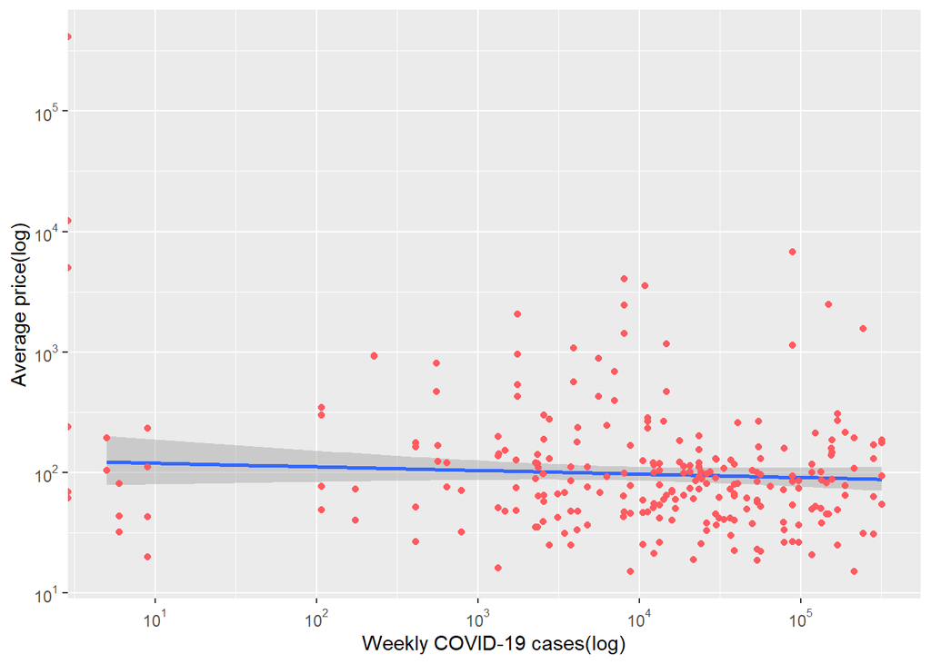

### Scatterplot(2) of average price (log) vs weekly COVID-19 cases by country

Since the previous scatterplot shows no correlation between the average price and weekly COVID-19 cases, we decided to investigate whether the country may affect the results. The finding from the second scatterplot is as follows: the correlations do differ per country – showing either a positive or negative linear relationship between the two variables, while still, quite a few countries such as the Netherlands, Germany, and Belgium show no correlation.

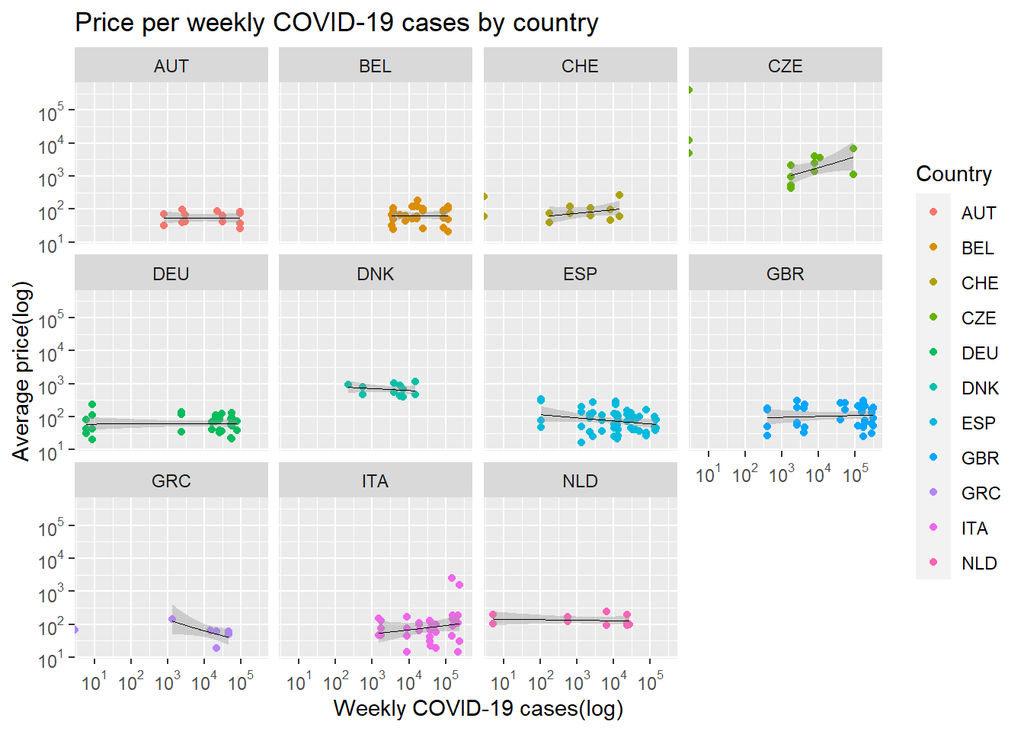